# An agent-based network model of injection drug use and HCV

Forrest W. Crawford

# Setting

Consider a closed population of $N$ injection drug users at risk of Hepatitis C Virus (HCV). The members of the population are connected by a *needle sharing network*. When an infectious (HCV+) individual shares a needle with a susceptible (HCV-) individual, the virus may be transmitted.

Each connected pair of individuals shares a needle with rate $\lambda$. When an infected individual shares a needle with an uninfected individual, transmission happens with probability $p$. Therefore the rate of infection from a single infected needle sharing partner is the product, $p\lambda$. Assume that HCV infection renders an individual instantly infectious.

# Network model

We will represent the needle sharing network as a symmetric contact matrix $\mathbf{A}$ whose rows and columns correspond to individuals. Assume that links in this matrix are drawn independently from the Bernoulli$(q)$ distribution:

$$A_{ij} \sim \text{Bernoulli}(q)$$

This is known as the homogeneous, Bernoulli, or Erdos-Renyi, network model.

# Transmission model

The rate of infection of a susceptible individual with $k$ infected neighbors is $k p \lambda$. Let $\mathbf{y}(t)=(y_1(t),\ldots,y_N(t))$ be the vector of infection indicators at time $t$, where $y_i(t)=1$ if $i$ is infected at time $t$ and zero otherwise. The matrix-vector product $\mathbf{s}(t) = \mathbf{A}\mathbf{y}(t)$ is the number of infected neighbors of each individual.

Only susceptible individuals are at risk of new infection, so
$$(1-\mathbf{y}(t))' \mathbf{s}(t)$$
is the number of infected individuals connected to each susceptible individual. The sum of these is the total number of “susceptible edges” along which HCV infection could pass.

Therefore, given the current infection indicators $\mathbf{y}(t)$, the waiting time to the next infection is
$$W \sim \text{Exponential}(p \lambda (1-\mathbf{y}(t))' \mathbf{A} \mathbf{y}(t))$$
Furthermore, the next infected individual is chosen with probability proportional to the corresponding entry in the product
$$(1-\mathbf{y}(t)) \circ (\mathbf{A} \mathbf{y}(t)) .$$

# Goal

We wish to construct a realistic model of injection drug use, needle sharing, and HCV in a small population of injection drug users. We will assume there is one initial HCV infection in the population, and we will assess the spread of infection up to a maximum time horizon of 1 year, with time measured in days. We will use this model to evaluate the possible effects of hypothetical policy/education/healthcare interventions in the population.

Because the population is connected we expect the effects of interventions to be nonlinear and potentially complex.

To help you get started, below is code for an SI process on a network, starting with a single infected individual.

# Network SI model

```r
# the population size
N = 70

# the needle sharing connection
# probability as a function of the
# average degree
d_avg = 3
q = d_avg/(N - 1)

# the needle sharing rate once per day
lam = 1

# the transmission probability per
# sharing event
p = 0.01

# the transmission rate beta
bet = lam * p

# max time: one year, measured in days
tmax = 365

# set the infection indicator
y = rep(0, N)

# we will set person 1 to be infected at
# baseline
y[1] = 1

# set the infection time
ts = rep(NA, N)
ts[1] = 0

# set up a symmetric zero-diagonal
# contact matrix
A = matrix(0, nrow = N, ncol = N)
for (i in 1:(N - 1)) {
    for (j in (i + 1):N) {
        A[i, j] = rbinom(1, 1, q)
        A[j, i] = A[i, j]
    }
}
A[diag(A)] = 0
```

Now run the simulation. Make sure you understand how it works before changing anything!

```r
tcur = 0

while (tcur < tmax && any(y == 0)) {

    # the number of edges connected to each
    # susceptible unit that are attached to
    # an infected unit
    susc_edges = (1 - y) * (A %*% y)
    if (sum(susc_edges) == 0)
        break

    # the waiting time to the next infection
    w = rexp(1, bet * sum(susc_edges))

    # if this would put us over the time
    # horizon, stop
    if (tcur + w > tmax)
        break

    # choose the id of the next infected unit
    idx = sample(1:N, 1, prob = susc_edges)

    # mark this unit infected
    y[idx] = 1

    # record the infection time of the newly
    # infected unit
    ts[idx] = tcur + w

    # update the current time
    tcur = tcur + w
}

ts[y == 0] = Inf
```

Now let’s look at the infection times.

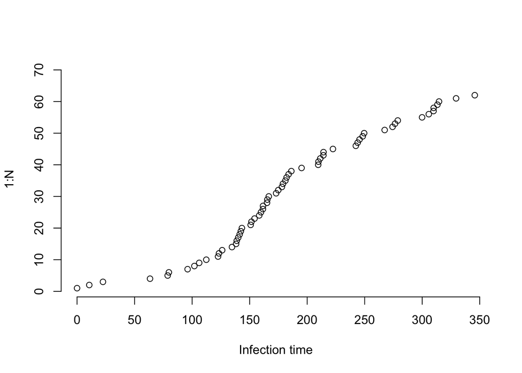

```r
plot(sort(ts), 1:N, bty = "n", xlab = "Infection time")
```

Let’s plot the network and see how the infection spreads. This is useful for visual intuition, but not necessary to answer any of the questions below.

```r
library(network)
```

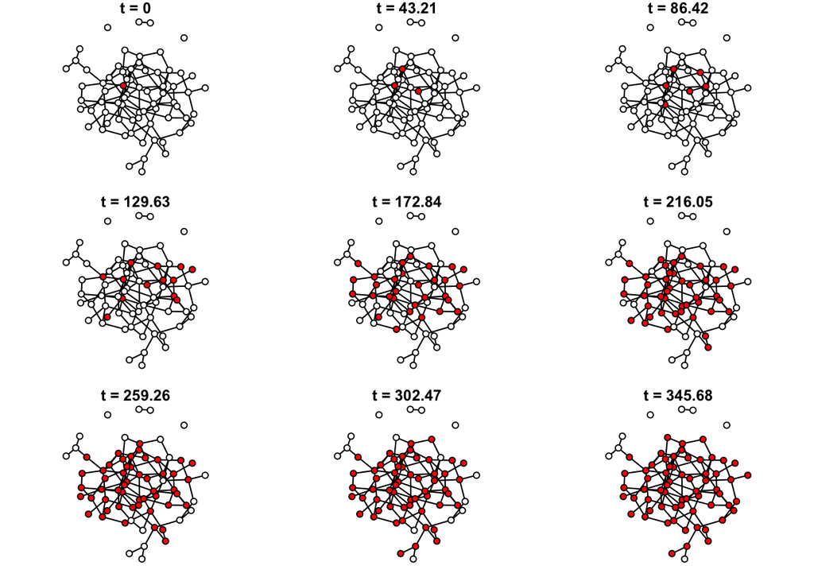

```r
plot_network_infections = function(t, lay) {
    set.seed(1)
    g = network(A, vertex.attr = list(y = ifelse(ts <=
        t, 1, 0)), matrix.type = "adjacency",
        directed = FALSE)
    plot(g, vertex.col = ifelse(get.vertex.attribute(g,
        "y"), "red", "white"), vertex.cex = 2,
        main = paste("t =", round(t, digits = 2)))
}

tseq = seq(0, max(ts[ts < Inf]), length.out = 9)
par(mfrow = c(3, 3), mar = c(1, 0, 1, 0))

for (t in tseq) {
    plot_network_infections(t, lay)
}
```

# Problems and questions

Create a function

```r
run_sim(lam, p, d_avg)
```

that runs the simulation once, with input variables $\lambda$, $p$, and the average degree in the network. The function should output the number of individuals infected with HCV at 1 year.

1. Before doing any programming, look at the simulation code above. It is very concise, and runs efficiently on a computer, even when the network consists of hundreds of individual. Why? Go line by line through the `while` loop to understand each part. Which part chooses the next infected individual? Why are there no rate parameters involved in this choice?
2. Using the default values of input parameters, what is the average number of infections that occur in the population over one year?
3. Public health authorities attempt to help injection drug users stop using drugs by providing opioid agonist therapy (OAT) free of charge, thereby reducing the frequency $\lambda$ of drug use and needle sharing. Assess the impact of reducing the frequency of drug use and needle sharing by plotting the distribution of total infections by $\lambda$ as it ranges from 0 to 1.
4. Public health authorities decide that they cannot limit injection drug use, but they can supply drug users with clean needles, thereby reducing the average number of needle sharing partners they have. Assess the impact of reducing the average degree by plotting the distribution of total infections by the average degree as it ranges from 1 to 10.
5. Drug use epidemiologists criticize the model described above because it assumes that all individuals are the same in their drug use characteristics, and differ only in their location in the network. You decide to remedy this by defining the needle sharing rate $\lambda_i$ for susceptible individuals as a function of individualistic covariates. You decide to model
   $$\lambda_i = \exp[z_i]$$
   where
   $$z_i \sim \text{Normal}(0,\sigma^2)$$
   You will need to rewrite the part of the simulation code that defined $\lambda$ and the part that computes the waiting time to the next infection. Assess the impact of this individualistic variation by plotting total infections by $\sigma^2$ as it ranges from 0 to 3.
6. Extra Credit: Infectious disease epidemiologists criticize the model above because it assumes that individuals are infectious forever after contracting HCV. In reality, individuals may be diagnosed and treated with effective drugs that cure the infection. Rewrite this model as an agent-based stochastic SIR model, and assess the total number of infections as a function of the “removal rate” $\gamma$.